# Wykorzystanie analizy skupień do grupowania województw Polski ze względu na wybrane cechy dotyczące szkolnictwa wyższego

Karol Doliński

Wydział Zarządzania AGH

## 1. Wprowadzenie

W Polsce obecnie funkcjonują 392 uczelnie wyższe, na których kształci się ponad 1.2 mln studentów. Liczba ta systematycznie spada, w roku akademickim 2007/08 wynosiła blisko 2 mln. Dzieje się to między innymi dlatego, że jeszcze niedawno powszechne stwierdzenie, iż ukończenie studiów wyższych jest gwarantem lepszej jakości życia, przechodzi do lamusa. Wysokość zarobków, realizacja zawodowa coraz mniej jest utożsamiana z posiadaniem dyplomu uczelni wyższej. Blisko 2/3 uczelni w Polsce to placówki niepubliczne, a studenci zaoczni stanowią 1/3 ogółu. W roku akademickim 2018/2019 studiowało na polskich uczelniach prawie 80 tys. cudzoziemców.[^1]

Jakość szkolnictwa, to jak jest atrakcyjne w danym województwie, można ocenić nie tylko odsetkiem osób posiadających wyższe wykształcenie, ale również stosunkiem kadry profesorskiej do ogółu nauczycieli akademickich, a także ilością studentów z zagranicy czy odsetkiem studentów z przyznanych stypendium w stosunku do wszystkich osób studiujących.

Celem pracy jest pogrupowanie polskich województw w skupienia, ze względu na podobne cechy, które pozwolą ocenić jak szkolnictwo wyższe w danej jednostce administracyjnej zmieniło się pomiędzy 2010, 2014 a 2018 rokiem oraz gdzie poziom tego szkolnictwa, w oparciu o wybrane cechy, jest podobny.

## 2. Zbiór danych

Dane zostały zebrane w dniu 16.10.2020 z Banku Danych Lokalnych oraz z opracowań Głównego Urzędu Statystycznego:

- *Szkoły wyższe i ich finanse w 2010* r.
- *Szkoły wyższe i ich finanse w 2014* r.
- *Szkoły wyższe i ich finanse w 2018* r.

Omawiane dane dotyczą lat: 2010, 2014, 2018. Każda z 16 obserwacji dotyczy innego województwa.

## 3. Opis i analiza zmiennych

Wybrano następujące zmienne związane ze szkolnictwem wyższym w Polsce:

- $x_{1}$ - liczba studentów szkół wyższych na 10 tys. ludności;
- $x_{2}$ - liczba absolwentów szkół wyższych na 10 tys. ludności;
- $x_{3}$ - liczba uczestników studiów doktoranckich na 10 tys. ludności;
- $x_{4}$ - liczba uczestników studiów podyplomowych na 10 tys. ludności;
- $x_{5}$ - odsetek osób z tytułem profesora w ogóle pracowników akademickich;
- $x_{6}$ - liczba studentów przypadająych na jednego wykładowcę (pracownika akademickiego);
- $x_{7}$ - odsetek studentów cudzoziemców studiujących na polskich uczelniach;
- $x_{8}$ - udział zarejestrowanych osób bezrobotnych z wyższym wykształceniem w liczbie osób w wieku produkcyjnym [%];
- $x_{9}$ - odsetek studentów orzymujacych stypendium socjalne;
- $x_{10}$ - odsetek studentów orzymujacych stypendium rektora.

### 3.1. Statystyki opisowe

Statystyki opisowe zawierają najważniejsze właściwości zmiennych, dzięki którym już na początku badań można wyciągnąć wstępne wnioski. W omawianych badaniach również w kontekście zmian wartości na przestrzeni lat.

| Zmienna | Rok | Średnia | Odchyl..standardowe | Mediana | Min. | Max. | Skośność | Kurtoza |
| --- | --- | --- | --- | --- | --- | --- | --- | --- |
| X1 | 2010 | 116.88 | 21.52 | 111.5 | 73 | 153 | -0.07 | -0.98 |
| X1 | 2014 | 102.25 | 25.8 | 96.5 | 51 | 156 | 0.31 | -0.24 |
| X1 | 2018 | 77.19 | 24.39 | 72.5 | 31 | 128 | 0.32 | -0.52 |
| X2 | 2010 | 439.88 | 101.67 | 428.5 | 258 | 635 | 0.4 | -0.63 |
| X2 | 2014 | 346.69 | 104.53 | 317 | 176 | 545 | 0.46 | -0.86 |
| X2 | 2018 | 285.56 | 95.86 | 262.5 | 131 | 457 | 0.36 | -1.08 |
| X3 | 2010 | 7.62 | 5.33 | 6.7 | 1 | 18.4 | 0.48 | -1.01 |
| X3 | 2014 | 9.3 | 5.88 | 7.7 | 2.4 | 20.9 | 0.62 | -0.87 |
| X3 | 2018 | 8.53 | 4.98 | 7.6 | 2.4 | 18.5 | 0.57 | -0.8 |
| X4 | 2010 | 41.34 | 18.99 | 38.15 | 17.8 | 105.7 | 2.27 | 5.43 |

[output cut: 20 more lines]

Tab. 1. Statystyki opisowe zmiennych.

#### X1

Średnia liczba studentów szkół wyższych na 10 tys. ludności ma tendencję spadkową i w 2018 roku wynosiła około 77 z odchyleniem standardowym o wartości około 25 jednostek (osób). Mediana jest zbliżona do średniej, co świadczy o umiarkowanej symetryczności badanej cechy. Skośność w 2018 roku jest prawostronna, co oznacza, że liczba studentów w większości województw jest niższa od średniej. Ujemna kurtoza wskazuje na słabą koncentrację cechy wokół średniej.

#### X2

Średnia liczba absolwentów szkół wyższych na 10 tys. ludności ma tendencję spadkową i w 2018 roku wynosiła około 286 z odchyleniem standardowym o wartości blisko 100 jednostek (osób). Mediana jest zbliżona do średniej, co świadczy o umiarkowanej symetryczności badanej cechy. Skośność we wszystkich badanych latach jest prawostronna, co oznacza, że liczba absolwentów w większości województw jest niższa od średniej.

#### X3

Średnia liczba uczestników studiów doktoranckich w latach 2010, 2014, 2018 oscyluje w okolicach 8 osób na z dużym odchyleniem o wartości 5-6 osób. Mediana jest zbliżona do średniej, co świadczy o umiarkowanej symetryczności badanej cechy. Skośność we wszystkich badanych latach jest prawostronna, co oznacza, że liczba uczestników studiów doktoranckich w większości województw jest niższa od średniej. Ujemna kurtoza wskazuje na słabą koncentrację cechy wokół średniej.

#### X4

Średnia liczba uczestników studiów podyplomowych w latach 2010, 2014, 2018 oscyluje w okolicach 30-40 osób na z dużym odchyleniem o wartości około 20 osób. Mediana jest zbliżona do średniej, co świadczy o umiarkowanej symetryczności badanej cechy. Skośność we wszystkich badanych latach jest prawostronna, co oznacza, że liczba uczestników studiów podyplomowych w większości województw jest niższa od średniej. Dodatnia kurtoza wskazuje na silną koncentrację cechy wokół średniej.

#### X5

Odsetek osób z tytułem profesora w ogóle pracowników akademickich utrzymuje się na stałym poziomie i średnio wynosi 0.25. Mediana jest bardzo bliska średniej, co świadczy o umiarkowanej symetryczności badanej cechy. Ujemna kurtoza wskazuje na słabą koncentrację cechy wokół średniej.

#### X6

Liczba studentów przypadających na jednego wykładowcę (pracownika akademickiego) maleje i w 2018 było to średnio 13 jednostek. Mediana jest zbliżona do średniej, co świadczy o umiarkowanej symetryczności badanej cechy. Skośność we wszystkich badanych latach jest prawostronna i maleje, co oznacza, że liczba studentów przypadających na jednego wykładowcę w większości województw jest niższa od średniej (za wyjątkiem 2018 roku). Ujemna kurtoza wskazuje na słabą koncentrację cechy wokół średniej.

#### X7

Odsetek studentów cudzoziemców studiujących na polskich uczelniach systematycznie wzrasta, w 2018 było to ponad 5% (wzrost o 4 p.p. w stosunku do roku 2010). Skośność we wszystkich badanych latach jest prawostronna, co oznacza, że odsetek studentów cudzoziemców studiujących na polskich uczelniach w większości województw jest niższy od średniej.

#### X8

Udział zarejestrowanych osób bezrobotnych z wyższym wykształceniem w liczbie osób w wieku produkcyjnym spadł w 2018 roku i wyniósł 0.61. Skośność we wszystkich badanych latach jest prawostronna, co oznacza, że udział zarejestrowanych osób bezrobotnych z wyższym wykształceniem w liczbie osób w wieku produkcyjnym w większości województw jest niższy od średniej. Ujemna kurtoza wskazuje na słabą koncentrację cechy wokół średniej.

#### X9

Średnio między 12-15% studentów otrzymuje stypendia socjalne. Skośność we wszystkich badanych latach jest prawostronna, co oznacza, że odsetek studentów otrzymujących stypendium socjalne w większości województw jest niższy od średniej. Ujemna kurtoza wskazuje na słabą koncentrację cechy wokół średniej.

#### X10

Odsetek studentów otrzymujących stypendia rektora spada i w 2018 roku wyniósł 8%. Mediana jest zbliżona do średniej, co świadczy o umiarkowanej symetryczności badanej cechy. Skośność we wszystkich badanych latach jest lewostronna, co oznacza, że odsetek studentów otrzymujących stypendium rektora w większości województw jest wyższy od średniej.

### 3.2. Współczynnik zmienności

Współczynnik zmienności poniżej 10% świadczy o małym zróżnicowaniu cechy, a jest to niepożądana własność zmiennej. Natomiast w badaniu omawiany współczynnik jest zawsze powyżej 10% (ze wszystkich badanych latach), dlatego podjęto decyzję o nieusuwaniu żadnej ze zmiennych.

|  | X1 | X2 | X3 | X4 | X5 | X6 | X7 | X8 | X9 | X10 |
| --- | --- | --- | --- | --- | --- | --- | --- | --- | --- | --- |
| 2010 | 0.184 | 0.231 | 0.700 | 0.459 | 0.110 | 0.150 | 0.627 | 0.261 | 0.357 | 0.159 |
| 2014 | 0.252 | 0.302 | 0.632 | 0.702 | 0.103 | 0.124 | 0.618 | 0.275 | 0.384 | 0.116 |
| 2018 | 0.316 | 0.336 | 0.584 | 0.640 | 0.108 | 0.119 | 0.510 | 0.347 | 0.433 | 0.111 |

Tab 2: Współczynnik zmienności dla omawianych zmiennych w latach 2010, 2014, 2018.

### 3.3. Korelacja pomiędzy zmiennymi

Współczynnik korelacji określa w jakim stopniu zmienne są współzależne. Występowanie silnie skorelowanych zmiennych (|p|>0.9, gdzie p - wsp. korelacji) jest niepożądane, gdyż te cechy będą powielać wnoszone przez siebie informacje.

#### 2010

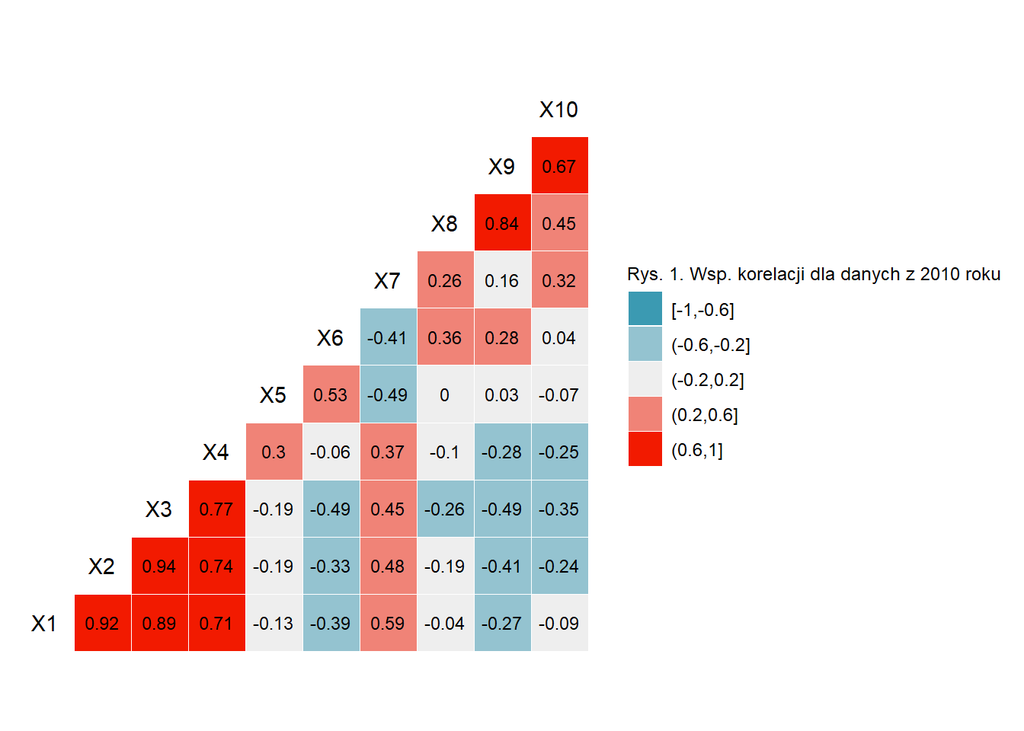

#### 2014

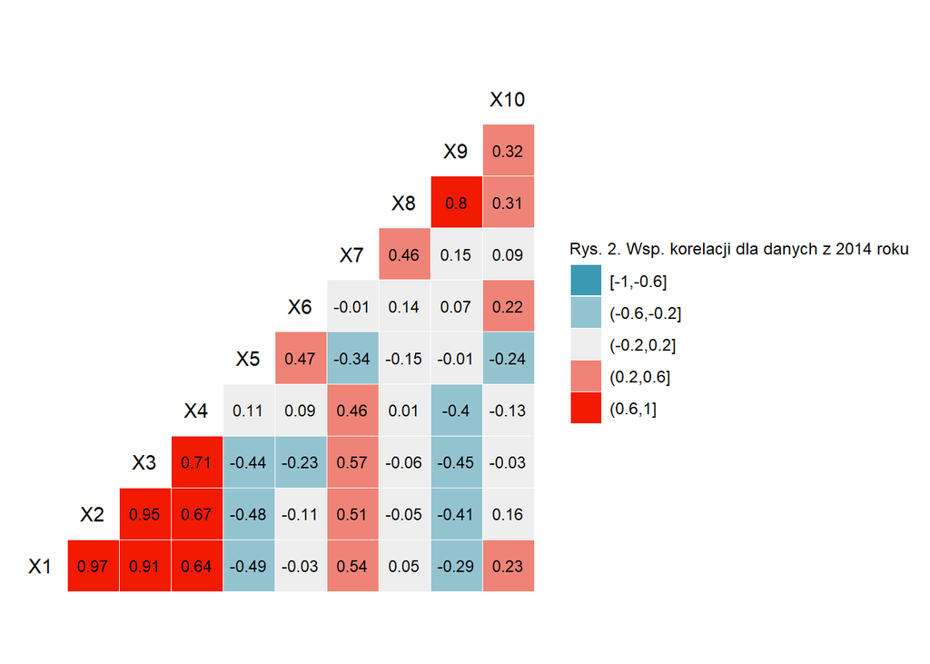

#### 2018

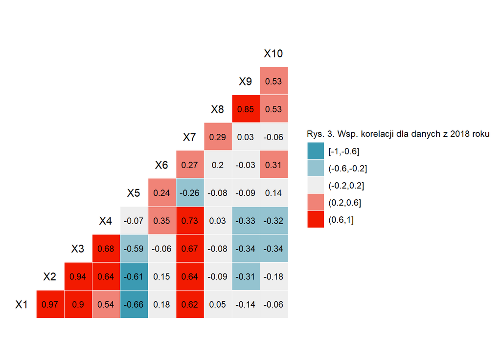

Na wszystkich trzy korelogramach widać, że zmienne $x_{1}$, $x_{2}$, $x_{3}$ są silnie skorelowane ze sobą nawzajem, dlatego podjęto decyzję o pozostawieniu tylko jednej z nich - $x_{1}$ (liczba studentów szkół wyższych na 10 tys. ludności).

### 3.4. Zmienne odstające i normalizacja danych

Ze względu na specyfikę omawianych obserwacji, tj. wszystkie województwa Polski, postanowiono nie usuwać obserwacji odstających. Dane zostały znormalizowane.

#### 2010

| Województwo | X1 | X4 | X5 | X6 | X7 | X8 | X9 | X10 |
| --- | --- | --- | --- | --- | --- | --- | --- | --- |
| DOLNOSLASKIE | 1.03 | 0.45 | -0.65 | 0.05 | 0.26 | -0.63 | -1.06 | -0.83 |
| KUJAWSKO-POMORSKIE | -0.6 | -0.48 | 0.7 | -0.1 | -0.98 | -0.63 | 0.12 | 0.67 |
| LUBELSKIE | 0.89 | 0.01 | -1.37 | -1.16 | 1.5 | 1.66 | 1.44 | 0.95 |
| LUBUSKIE | -2.04 | -1.24 | -0.48 | -0.37 | -0.67 | -0.63 | 0 | 0.22 |
| LODZKIE | 0.66 | -0.24 | 0.44 | -1.2 | -0.2 | -0.17 | -0.77 | -0.19 |
| MALOPOLSKIE | 1.31 | 0.47 | -1.15 | -0.65 | 0.11 | -0.17 | -0.37 | -0.22 |
| MAZOWIECKIE | 1.68 | 3.39 | 1.42 | 0.09 | 1.34 | -0.17 | -0.71 | -0.5 |
| OPOLSKIE | -0.41 | -0.32 | 1.13 | 1.75 | -0.82 | -0.63 | -0.8 | 0.44 |
| PODKARPACKIE | -0.88 | -0.82 | -0.39 | 1.47 | 0.72 | 1.66 | 1.55 | 0.25 |
| PODLASKIE | 0.33 | -0.47 | -1.2 | -0.56 | 1.96 | 0.74 | 1.06 | 2.66 |

[output cut: 6 more lines]

Tab. 3. Dane po normalizacji: 2010 rok

#### 2014

| Województwo | X1 | X4 | X5 | X6 | X7 | X8 | X9 | X10 |
| --- | --- | --- | --- | --- | --- | --- | --- | --- |
| DOLNOSLASKIE | 0.92 | 0.37 | -0.72 | 0.28 | 0.07 | -0.92 | -1 | 0.4 |
| KUJAWSKO-POMORSKIE | -0.28 | 0.09 | 1.01 | -0.01 | -0.74 | -0.53 | -0.11 | 1.07 |
| LUBELSKIE | 0.46 | -0.08 | -1.52 | -1.47 | 2.57 | 1.41 | 1.36 | 0.62 |
| LUBUSKIE | -1.99 | -0.95 | 1.64 | -0.34 | -0.74 | -0.92 | -0.08 | -2.49 |
| LODZKIE | -0.24 | -0.2 | 0.26 | -0.81 | -0.24 | -0.15 | -0.61 | 0.34 |
| MALOPOLSKIE | 2.08 | -0.01 | -1.44 | -0.47 | 0.45 | 0.24 | -0.31 | -0.34 |
| MAZOWIECKIE | 1.66 | 3.5 | 0.85 | 0.41 | 1.57 | 0.63 | -0.77 | -1.08 |
| OPOLSKIE | -0.2 | 0.01 | 1.35 | 1.65 | 0.07 | -0.92 | -0.58 | -0.6 |
| PODKARPACKIE | -0.44 | -0.63 | 0.28 | 2.2 | 1.07 | 1.79 | 1.58 | 1.07 |
| PODLASKIE | -0.05 | -0.69 | -1.18 | -0.9 | -0.24 | 0.63 | 1.22 | 0 |

[output cut: 6 more lines]

Tab. 4. Dane po normalizacji: 2014 rok

#### 2018

| Województwo | X1 | X4 | X5 | X6 | X7 | X8 | X9 | X10 |
| --- | --- | --- | --- | --- | --- | --- | --- | --- |
| DOLNOSLASKIE | 1.1 | 0.3 | -1.19 | 0.73 | 0.44 | -0.53 | -0.97 | 0.06 |
| KUJAWSKO-POMORSKIE | -0.34 | 0.19 | 0.44 | 0.54 | -0.67 | -0.53 | 0.01 | 0.43 |
| LUBELSKIE | 0.48 | 0.15 | -0.84 | -1.05 | 1.89 | 1.35 | 1.69 | 0.16 |
| LUBUSKIE | -1.89 | -1.14 | 1.17 | -1.39 | -1.58 | -1 | -0.47 | -1.99 |
| LODZKIE | -0.09 | -0.02 | 0.01 | -0.89 | 0.17 | -0.06 | -0.41 | 0.34 |
| MALOPOLSKIE | 2.08 | -0.12 | -1.62 | -0.8 | 0.21 | -0.06 | -0.09 | -0.46 |
| MAZOWIECKIE | 1.47 | 3.34 | -0.29 | 0.92 | 2 | 0.41 | -0.77 | -1.7 |
| OPOLSKIE | -0.66 | 0.55 | 1.75 | 0.95 | 1.05 | -0.53 | -0.55 | -0.15 |
| PODKARPACKIE | -0.29 | -0.93 | -0.02 | 1.71 | 0.21 | 1.82 | 1.86 | 1.34 |
| PODLASKIE | -0.09 | -0.58 | -1.42 | -1.05 | -0.48 | 0.88 | 1.29 | 0.39 |

[output cut: 6 more lines]

Tab. 5. Dane po normalizacji: 2018 rok

## 4. Analiza skupień

Ideą analizy skupień jest dzielenie wielowymiarowych zbiorów danych na skupienia, w taki sposób by elementy w poszczególnej grupie były do siebie jak najbardziej podobne, a jednocześnie jak najbardziej różniące się od elementów z innych grup. Podstawowe metody klasyfikacji dzieli się na:

- hierarchiczne
  - metoda najbliższego sąsiada
  - metoda najdalszego sąsiada
  - Warda
  - i inne
- optymalizacyjne
  - k-średnich
  - k-medoidów
  - PAM
  - i inne

W badaniach zdecydowano się wykorzystać dwie z nich: metodę k-średnich oraz metodę Warda.

### 4.1. Metoda k-średnich

Metodę k-średnich charakteryzuje to, że każda klasa reprezentowana jest przez środek ciężkości. Pożądany jest taki podział, dla którego miara tr(W) osiąga minimum, gdzie:

- W - macierz kowariancji wewnątrzklasowej;
- kr - ślad macierzy. [^2]

Wybór liczby skupień w metodzie k-średnich niekiedy odbywa się za pomocą metod eksperckich. Natomiast w poniższych badanich została wykorzystana metoda Silhouette przy wyborze liczby skupień.

Metoda Silhouette służy do oceny jakości grupowania. Miarę wyznacza się ze wzoru: $s(i) = \frac{b(i) - a(i)}{max\{a(i), b(i)\} }$ gdzie:

- $i$ - obserwacja;
- $a(i)$ - średnia odległość od reszty obserwacji z tej samej grupy;
- $b(i)$ - najniższa średnia odległość obserwacji i od każdej z grup, do której i nie należy [^3].

Wyniki kształtują się następująco:

#### 2010

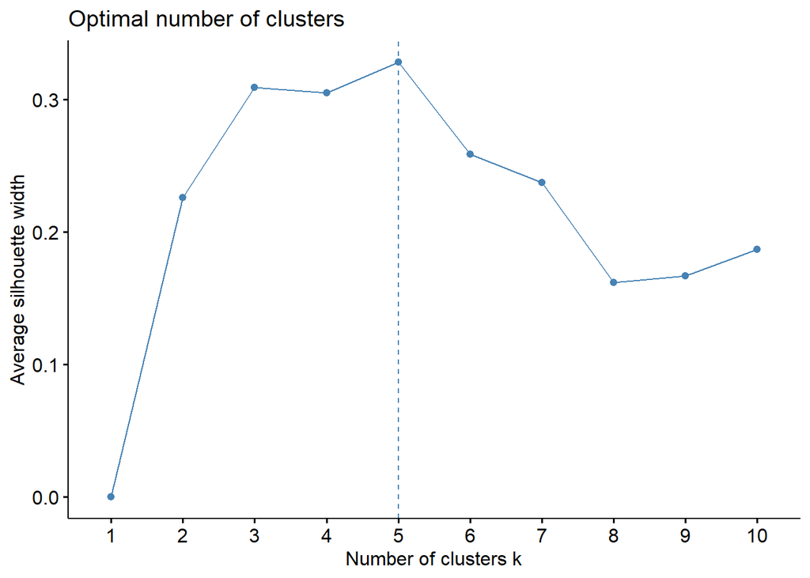

Rys. 4. Liczba optymalnych klas dla danych z 2010 roku.

#### 2014

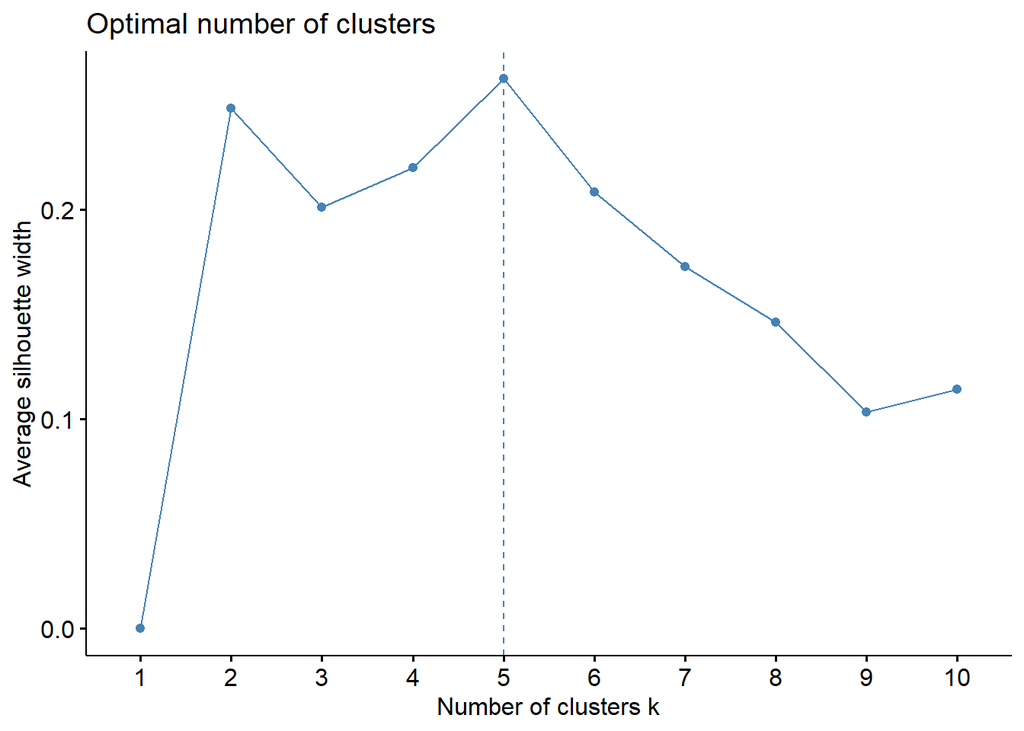

Rys. 5. Liczba optymalnych klas dla danych z 2014 roku.

#### 2018

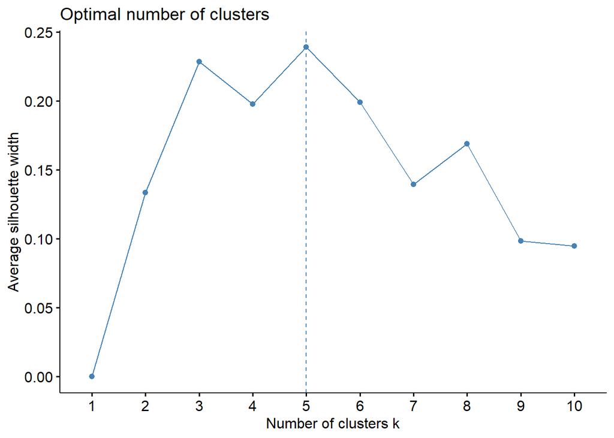

Rys. 6. Liczba optymalnych klas dla danych z 2018 roku.

#### 4.1.1. Interpretacja wyników danych aktualnych: 2018 rok

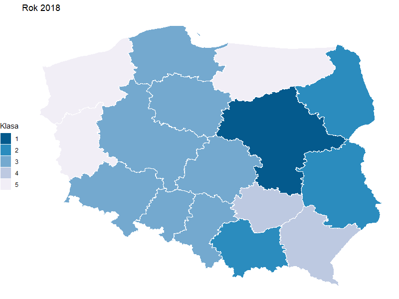

##### Klasa 1

|  | X1 | X4 | X5 | X6 | X7 | X8 | X9 | X10 |
| --- | --- | --- | --- | --- | --- | --- | --- | --- |
| MAZOWIECKIE | 113 | 109.3 | 0.24 | 14.48 | 10.4 | 0.7 | 0.08 | 0.07 |

Województwo: MAZOWIECKIE

Klasa ta charakteryzuje się największą liczbą studentów i uczestników studiów podyplomowych (na 10 tys. mieszkańców) wśród wszystkich klas. Wartości te są znaczenie powyżej średniej i warto podkreślić, iż liczba uczestników studiów podyplomowych (na 10 tys. mieszkańców) w województwie mazowieckim jest ponad trzykrotnie wyższa niż średnia krajowa. Klasę cechuje również największy odsetek studentów z zagranicy – ponad 10%.

##### Klasa 2

|  | X1 | X4 | X5 | X6 | X7 | X8 | X9 | X10 |
| --- | --- | --- | --- | --- | --- | --- | --- | --- |
| LUBELSKIE | 89 | 38.1 | 0.22 | 11.42 | 10.1 | 0.9 | 0.21 | 0.08 |
| MALOPOLSKIE | 128 | 32.1 | 0.20 | 11.81 | 5.7 | 0.6 | 0.12 | 0.08 |
| PODLASKIE | 75 | 21.9 | 0.21 | 11.42 | 3.9 | 0.8 | 0.19 | 0.09 |

Województwo: LUBELSKIE, MAŁOPOLSKIE, PODLASKIE

W województwach klasy 2 studiowało między 75 a 128 osób na 10 tys. w 2018 roku, co jest wartością bliską średniej dla całego kraju. Widać bardzo duże podobieństwo w kontekście liczby studentów przypadających na jednego wykładowcę. Zauważalny jest duży odsetek studentów pobierających stypendia socjalne w województwie lubelskim i podlaskim.

##### Klasa 3

|  | X1 | X4 | X5 | X6 | X7 | X8 | X9 | X10 |
| --- | --- | --- | --- | --- | --- | --- | --- | --- |
| DOLNOSLASKIE | 104 | 41.5 | 0.21 | 14.19 | 6.3 | 0.5 | 0.07 | 0.08 |
| KUJAWSKO-POMORSKIE | 69 | 39.1 | 0.25 | 13.89 | 3.4 | 0.5 | 0.12 | 0.09 |
| LODZKIE | 75 | 34.5 | 0.24 | 11.67 | 5.6 | 0.6 | 0.10 | 0.08 |
| OPOLSKIE | 61 | 47.2 | 0.29 | 14.52 | 7.9 | 0.5 | 0.09 | 0.08 |
| POMORSKIE | 93 | 34.6 | 0.26 | 14.36 | 4.6 | 0.5 | 0.08 | 0.08 |
| SLASKIE | 68 | 31.2 | 0.22 | 13.92 | 4.1 | 0.4 | 0.06 | 0.07 |
| WIELKOPOLSKIE | 88 | 29.1 | 0.25 | 12.95 | 4.9 | 0.3 | 0.09 | 0.09 |

Województwo: DOLNOŚLĄSKIE, ŁÓDZKIE, KUJAWSKO-POMORSKIE, OPOLSKIE, POMORSKIE, WIELKOPOLSKIE, ŚLĄSKIE

Blisko połowa województw, bo aż siedem, należy do klasy trzeciej. Geograficznie jest to środkowo-zachodnia część Polski. Liczba studentów na 10 tys. ludności jest zbliżona do średniej krajowej. Udział zarejestrowanych osób bezrobotnych z wyższym wykształceniem w liczbie osób w wieku produkcyjnym jest mało zróżnicowany, podobnie jak liczba studentów nagrodzonych stypendium rektora.

##### Klasa 4

|  | X1 | X4 | X5 | X6 | X7 | X8 | X9 | X10 |
| --- | --- | --- | --- | --- | --- | --- | --- | --- |
| PODKARPACKIE | 70 | 14.0 | 0.24 | 15.70 | 5.7 | 1 | 0.22 | 0.09 |
| SWIETOKRZYSKIE | 57 | 31.5 | 0.28 | 14.44 | 3.5 | 1 | 0.18 | 0.10 |

Województwo: PODKARPACKIE, ŚWIĘTOKRZYSKIE

Liczba studentów jak i uczestników studiów podyplomowych w tej klasie jest poniżej średniej. Cechą charakterystyczną jest najwyższy odsetek studentów wspieranych przyznanymi stypendiami socjalnymi – prawie dwukrotnie wyższy od średniej (18 i 22%). Również udział zarejestrowanych osób bezrobotnych z wyższym wykształceniem w liczbie osób w wieku produkcyjnym jest najwyższy spośród wszystkich klas.

##### Klasa 5

|  | X1 | X4 | X5 | X6 | X7 | X8 | X9 | X10 |
| --- | --- | --- | --- | --- | --- | --- | --- | --- |
| LUBUSKIE | 31 | 9.5 | 0.27 | 10.89 | 1.0 | 0.4 | 0.10 | 0.06 |
| WARMINSKO-MAZURSKIE | 58 | 17.2 | 0.25 | 12.12 | 1.4 | 0.6 | 0.16 | 0.08 |
| ZACHODNIOPOMORSKIE | 56 | 26.6 | 0.25 | 11.00 | 3.9 | 0.5 | 0.08 | 0.08 |

Województwo: LUBUSKIE, WARMIŃSKO-MAZURSKIE, ZACHODNIOPOMORSKIE

Klasa ta charakteryzuje się najniższą liczbą studentów i uczestników studiów podyplomowych na 10 tys. ludności. Również odsetek studiujących cudzoziemców jest najmniejszy i wynosi 1-3.9%. Pozostałe cechy oscylują wokół średniej krajowej.

##### Wszystkie klasy

|  | X1 | X4 | X5 | X6 | X7 | X8 | X9 | X10 |
| --- | --- | --- | --- | --- | --- | --- | --- | --- |
| DOLNOSLASKIE | 104 | 41.5 | 0.21 | 14.19 | 6.3 | 0.5 | 0.07 | 0.08 |
| KUJAWSKO-POMORSKIE | 69 | 39.1 | 0.25 | 13.89 | 3.4 | 0.5 | 0.12 | 0.09 |
| LUBELSKIE | 89 | 38.1 | 0.22 | 11.42 | 10.1 | 0.9 | 0.21 | 0.08 |
| LUBUSKIE | 31 | 9.5 | 0.27 | 10.89 | 1.0 | 0.4 | 0.10 | 0.06 |
| LODZKIE | 75 | 34.5 | 0.24 | 11.67 | 5.6 | 0.6 | 0.10 | 0.08 |
| MALOPOLSKIE | 128 | 32.1 | 0.20 | 11.81 | 5.7 | 0.6 | 0.12 | 0.08 |
| MAZOWIECKIE | 113 | 109.3 | 0.24 | 14.48 | 10.4 | 0.7 | 0.08 | 0.07 |
| OPOLSKIE | 61 | 47.2 | 0.29 | 14.52 | 7.9 | 0.5 | 0.09 | 0.08 |
| PODKARPACKIE | 70 | 14.0 | 0.24 | 15.70 | 5.7 | 1.0 | 0.22 | 0.09 |
| PODLASKIE | 75 | 21.9 | 0.21 | 11.42 | 3.9 | 0.8 | 0.19 | 0.09 |
| POMORSKIE | 93 | 34.6 | 0.26 | 14.36 | 4.6 | 0.5 | 0.08 | 0.08 |
| SLASKIE | 68 | 31.2 | 0.22 | 13.92 | 4.1 | 0.4 | 0.06 | 0.07 |
| SWIETOKRZYSKIE | 57 | 31.5 | 0.28 | 14.44 | 3.5 | 1.0 | 0.18 | 0.10 |
| WARMINSKO-MAZURSKIE | 58 | 17.2 | 0.25 | 12.12 | 1.4 | 0.6 | 0.16 | 0.08 |
| WIELKOPOLSKIE | 88 | 29.1 | 0.25 | 12.95 | 4.9 | 0.3 | 0.09 | 0.09 |
| ZACHODNIOPOMORSKIE | 56 | 26.6 | 0.25 | 11.00 | 3.9 | 0.5 | 0.08 | 0.08 |

W województwach klasy 2 odsetek przyznanych stypendiów socjalnych jest znacznie wyższy od średniej, co jest spowodowane m. in. wysokim wskaźnikiem realnego ubóstwa [^4]. W roku 2018 ubóstwem dochodowym było dotkniętych między 15 a 26% gospodarstw domowych.

Odsetek studentów cudzoziemców pomiędzy klasą pierwszą a piątą jest zróżnicowany. W pozostałych klasach ten odsetek jest bliski średniej i oscyluje wokół 5%. Tak wysoki wskaźnik na mazowszu spowodowany jest dużą popularnością stolicy wśród studentów z zagranicy oraz bagatą ofertą uczelni w tym mieście.

#### 4.1.2. Zestawienie wyników dla lat: 2010, 2014, 2018

Przeprowadzone badania wskazały do której grupy należy dane województwo. Wyniki zostały zaprezentowane na poniższych mapach:

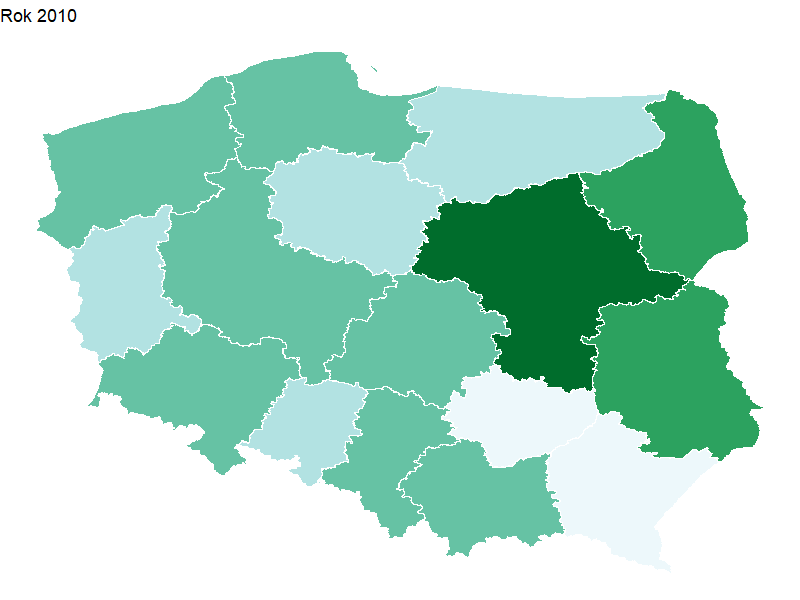

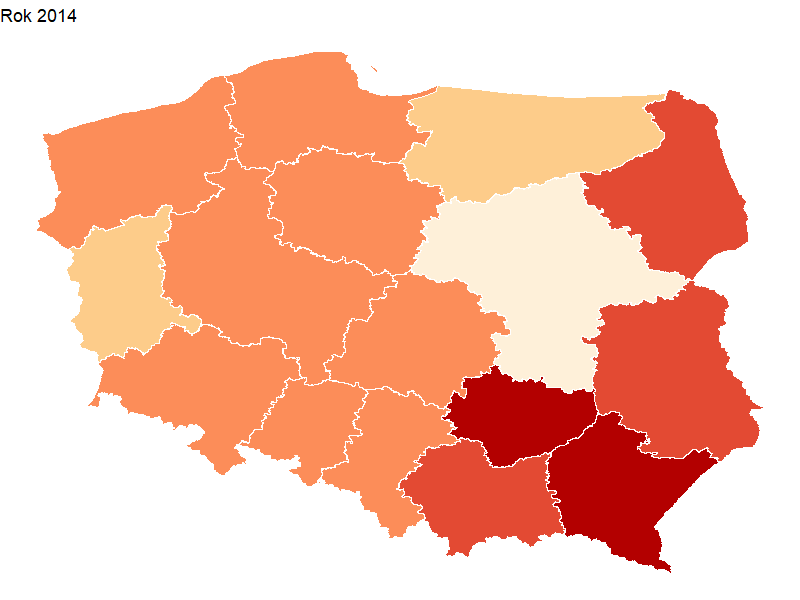

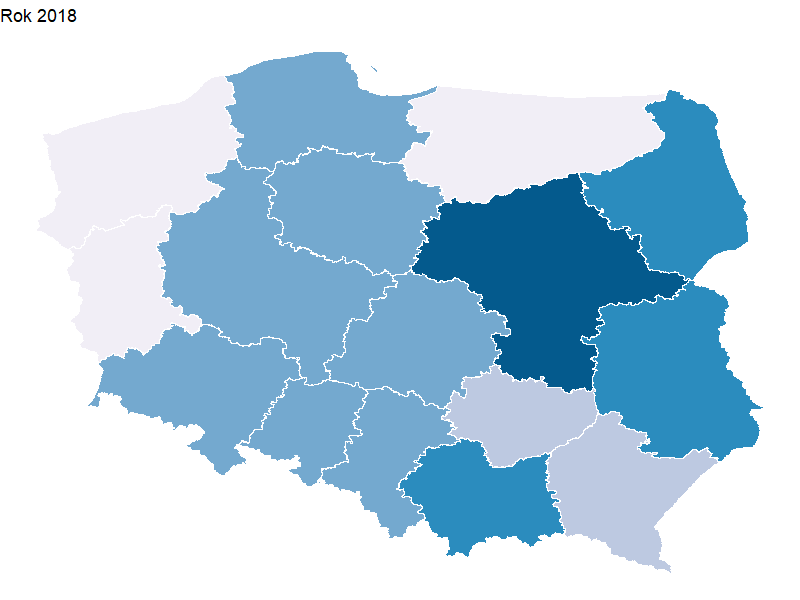

Najważniejszą rzeczą wynikającą z zestawienia jest fakt, iż w latach 2010, 2014 i 2018 nie nastąpiły żadne drastyczne zmiany w podziale na klasy, tzn. żadne województwo nie zmieniło się w sposób diametralny jeśli chodzi o np. gwałtowny skok liczy studentów na 10 tys. mieszkańców czy odsetek studentów z zagranicy lub odsetek przyznanych stypendiów socjalnych.

Województwa podkarpackie i świętokrzyskie cały czas przez te latą są klasyfikowane w jednej klasie, która charakteryzuje się liczbą studentów jak i uczestników studiów podyplomowych poniżej średniej. Cechą charakterystyczną jest najwyższy odsetek studentów wspieranych przyznanymi stypendiami socjalnymi – prawie dwukrotnie wyższy od średniej. Również udział zarejestrowanych osób bezrobotnych z wyższym wykształceniem w liczbie osób w wieku produkcyjnym jest najwyższy spośród wszystkich klas.

Województwo mazowieckie stanowi osobną klasę zarówno w 2010, 2014 jak i 2018 roku. Klasa ta charakteryzuje się największą liczbą studentów i uczestników studiów podyplomowych (na 10 tys. mieszkańców) wśród wszystkich klas. Wartości te są znaczenie powyżej średniej. Klasę cechuje również największy odsetek studentów z zagranicy.

Województwo małopolskie, które w 2010 roku znajdowało się w klasie, w której wszystkie wartości zmiennych są bliskie średniej, zostało sklasyfikowane w późniejszych latach wśród województw wschodnich: podlaskiego i lubelskiego, które to cechuje najwyższy wskaźnik ubóstwa, a tym samym liczba przyznanych stypendiów socjalnych. Wg danych GUS z 2010 i 2014 roku w województwach środkowo-zachodniej Polski wskaźnik ubóstwa poprawił się bardziej niż w Małopolsce, co miało m. in. wpływ na ilość przyznawanych stypendiów socjalnych, a tym samym na zmianę klasy tego województwa przy dokonywaniu podziału w latach 2014, 2018.

Województwa pomorskie, wielkopolskie, dolnośląskie, śląskie stale utrzymują się w klasie o najbardziej zbliżonych do średniej wartościach zmiennych. Natomiast województwa warmińsko-mazurskie oraz lubuskie w każdym roku są w klasie o najmniejszej liczbie studentów na 10 tys. ludności. Tendencja ta jest stała.

### 4.2. Metoda Warda

Metodę Warda cechuje to, że do oszacowania odelgłości między skupieniami wykorzystuje się ANOVA (analizę wariancji). Celem jest minimalizacja sumy kwadratów odchyleń wewnątrz skupień [^5].

Wybóru liczby skupień w metodzie Warda można dokonać w wykorzystaniem kilku wskaźników. Najpier zdecydowano się rozpatrzeć metodę Silhouette. Wyniki kształtują się następująco:

#### 2010

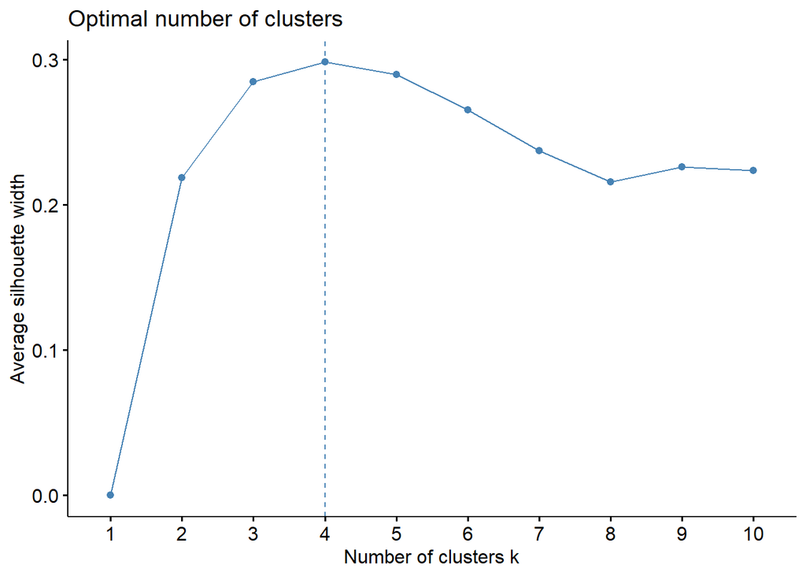

Rys. 7. Liczba optymalnych klas dla danych z 2010 roku.

#### 2014

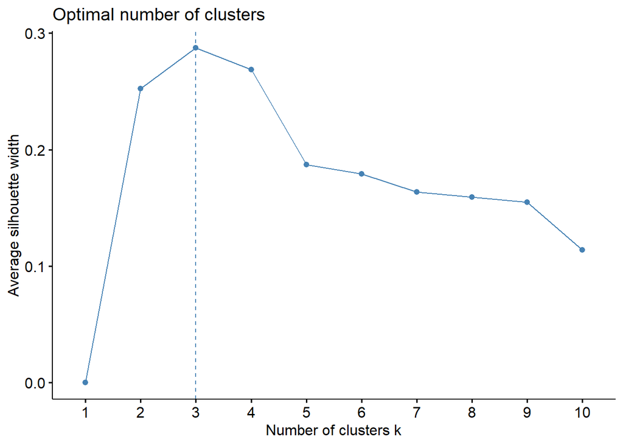

Rys. 8. Liczba optymalnych klas dla danych z 2014 roku.

#### 2018

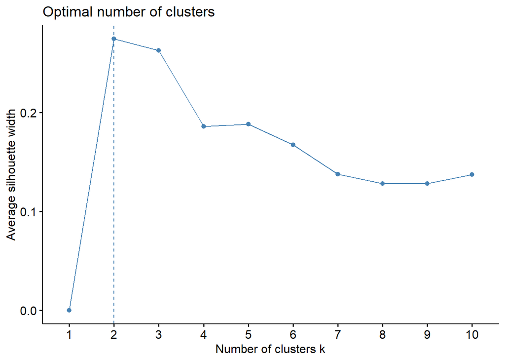

Rys. 9. Liczba optymalnych klas dla danych z 2018 roku.

W związku z tym, że metoda Silhouette wskazuje różne optymalne ilości klas (w zależności od roku), zdecydowano się wyliczyć wartości indeksu Bakera i Huberta dla k = 2, 3, 4 i wybrać taką liczbę klas, dla której indeks przyjmuje największą wartość.

|  | k = 2 | k = 3 | k = 4 |
| --- | --- | --- | --- |
| 2010 | 0.4452799 | 0.6409210 | 0.8220956 |
| 2014 | 0.1929825 | 0.2981638 | 0.5144033 |
| 2018 | 0.2241715 | 0.2812591 | 0.5042735 |

Tab 1: Współczynnik G2 - Bakera i Huberta

Największa wartość indeksu Bakera i Huberta (zarówno dla 2010, jak i 2014 oraz 2018 roku) występuje przy podziale zbioru na cztery klasy. Dlatego na tyle klas zdecydowano się podzielić województwa.

#### 4.2.1. Interpretacja wyników danych aktualnych: 2018 rok

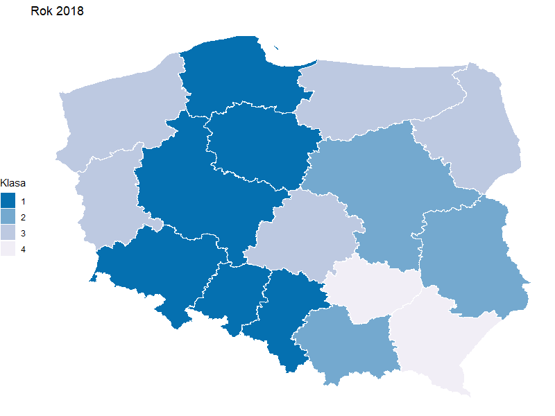

##### Klasa 1

|  | X1 | X4 | X5 | X6 | X7 | X8 | X9 | X10 |
| --- | --- | --- | --- | --- | --- | --- | --- | --- |
| DOLNOSLASKIE | 104 | 41.5 | 0.21 | 14.19 | 6.3 | 0.5 | 0.07 | 0.08 |
| KUJAWSKO-POMORSKIE | 69 | 39.1 | 0.25 | 13.89 | 3.4 | 0.5 | 0.12 | 0.09 |
| OPOLSKIE | 61 | 47.2 | 0.29 | 14.52 | 7.9 | 0.5 | 0.09 | 0.08 |
| POMORSKIE | 93 | 34.6 | 0.26 | 14.36 | 4.6 | 0.5 | 0.08 | 0.08 |
| SLASKIE | 68 | 31.2 | 0.22 | 13.92 | 4.1 | 0.4 | 0.06 | 0.07 |
| WIELKOPOLSKIE | 88 | 29.1 | 0.25 | 12.95 | 4.9 | 0.3 | 0.09 | 0.09 |

Województwo: DOLNOŚLĄSKIE, KUJAWSKO-POMORSKIE, OPOLSKIE, POMORSKIE, ŚLĄSKIE, WIELKOPOLSKIE

##### Klasa 2

|  | X1 | X4 | X5 | X6 | X7 | X8 | X9 | X10 |
| --- | --- | --- | --- | --- | --- | --- | --- | --- |
| LUBELSKIE | 89 | 38.1 | 0.22 | 11.42 | 10.1 | 0.9 | 0.21 | 0.08 |
| MALOPOLSKIE | 128 | 32.1 | 0.20 | 11.81 | 5.7 | 0.6 | 0.12 | 0.08 |
| MAZOWIECKIE | 113 | 109.3 | 0.24 | 14.48 | 10.4 | 0.7 | 0.08 | 0.07 |

Klasa cechuje się liczbą studentów (na 10 tys. ludności) wyższą niż średnia. Podobna tendencja występuje w odniesieniu do odsetka studentów cudzoziemców, zwłaszcza na Mazowszu. Jest to klasa zróżnicowana między innymi przez liczbę osób dostających stypendia socjalne i liczbę uczestników studiów podyplomowych.

##### Klasa 3

|  | X1 | X4 | X5 | X6 | X7 | X8 | X9 | X10 |
| --- | --- | --- | --- | --- | --- | --- | --- | --- |
| LUBUSKIE | 31 | 9.5 | 0.27 | 10.89 | 1.0 | 0.4 | 0.10 | 0.06 |
| LODZKIE | 75 | 34.5 | 0.24 | 11.67 | 5.6 | 0.6 | 0.10 | 0.08 |
| PODLASKIE | 75 | 21.9 | 0.21 | 11.42 | 3.9 | 0.8 | 0.19 | 0.09 |
| WARMINSKO-MAZURSKIE | 58 | 17.2 | 0.25 | 12.12 | 1.4 | 0.6 | 0.16 | 0.08 |
| ZACHODNIOPOMORSKIE | 56 | 26.6 | 0.25 | 11.00 | 3.9 | 0.5 | 0.08 | 0.08 |

Województwo: LUBUSKIE, ŁÓDZKIE, PODLASKIE, WARMIŃSKO-MAZURSKIE, ZACHODNIOPOMORSKIE

Charakterystyczne dla klasy jest to, że liczba zarówno studentów jak i uczestników studiów podyplomowych jest niższa niż średnia. Podobnie kwestia liczby studentów przypadających na jednego pracownika akademickiego.

##### Klasa 4

|  | X1 | X4 | X5 | X6 | X7 | X8 | X9 | X10 |
| --- | --- | --- | --- | --- | --- | --- | --- | --- |
| PODKARPACKIE | 70 | 14.0 | 0.24 | 15.70 | 5.7 | 1 | 0.22 | 0.09 |
| SWIETOKRZYSKIE | 57 | 31.5 | 0.28 | 14.44 | 3.5 | 1 | 0.18 | 0.10 |

Województwo: ŚWIĘTOKRZYSKIE, PODKARPACKIE

##### Wszystkie klasy

|  | X1 | X4 | X5 | X6 | X7 | X8 | X9 | X10 |
| --- | --- | --- | --- | --- | --- | --- | --- | --- |
| DOLNOSLASKIE | 104 | 41.5 | 0.21 | 14.19 | 6.3 | 0.5 | 0.07 | 0.08 |
| KUJAWSKO-POMORSKIE | 69 | 39.1 | 0.25 | 13.89 | 3.4 | 0.5 | 0.12 | 0.09 |
| LUBELSKIE | 89 | 38.1 | 0.22 | 11.42 | 10.1 | 0.9 | 0.21 | 0.08 |
| LUBUSKIE | 31 | 9.5 | 0.27 | 10.89 | 1.0 | 0.4 | 0.10 | 0.06 |
| LODZKIE | 75 | 34.5 | 0.24 | 11.67 | 5.6 | 0.6 | 0.10 | 0.08 |
| MALOPOLSKIE | 128 | 32.1 | 0.20 | 11.81 | 5.7 | 0.6 | 0.12 | 0.08 |
| MAZOWIECKIE | 113 | 109.3 | 0.24 | 14.48 | 10.4 | 0.7 | 0.08 | 0.07 |
| OPOLSKIE | 61 | 47.2 | 0.29 | 14.52 | 7.9 | 0.5 | 0.09 | 0.08 |
| PODKARPACKIE | 70 | 14.0 | 0.24 | 15.70 | 5.7 | 1.0 | 0.22 | 0.09 |
| PODLASKIE | 75 | 21.9 | 0.21 | 11.42 | 3.9 | 0.8 | 0.19 | 0.09 |
| POMORSKIE | 93 | 34.6 | 0.26 | 14.36 | 4.6 | 0.5 | 0.08 | 0.08 |
| SLASKIE | 68 | 31.2 | 0.22 | 13.92 | 4.1 | 0.4 | 0.06 | 0.07 |
| SWIETOKRZYSKIE | 57 | 31.5 | 0.28 | 14.44 | 3.5 | 1.0 | 0.18 | 0.10 |
| WARMINSKO-MAZURSKIE | 58 | 17.2 | 0.25 | 12.12 | 1.4 | 0.6 | 0.16 | 0.08 |
| WIELKOPOLSKIE | 88 | 29.1 | 0.25 | 12.95 | 4.9 | 0.3 | 0.09 | 0.09 |
| ZACHODNIOPOMORSKIE | 56 | 26.6 | 0.25 | 11.00 | 3.9 | 0.5 | 0.08 | 0.08 |

Wartości zmiennych: liczba studentów oraz osób uczęszczających na studia podyplomowe na 10 tys. ludności są bardzo zróżnicowane i nawet o połowę odbiegają od średniej krajowej. Warto podkreślić, że oprócz województwa mazowieckiego i małopolskiego (gdzie Warszawa i Kraków są dwoma największymi skupiskami studentów i uczelni) wysoko uplasowały się województwa środkowej polski (klasa 1).

Głównym rozróżnieniem klasy pierwszej i drugiej jest zarejestrowana liczba osób bezrobotnych z wyższym wykształceniem w liczbie osób w wieku produkcyjnym.

Odsetek studentów cudzoziemców poza klasą pierwszą jest zróżnicowany.

Różnica pomiędzy klasą trzecią a czwartą wynika głównie z różnicy odsetków osób ze stypendiami oraz udziałem zarejestrowanych osób bezrobotnych z wyższym wykształceniem w liczbie osób w wieku produkcyjnym (największa wartość dla podkarpacia i w. świętokrzyskiego).

#### 4.2.2. Zestawienie wyników dla lat: 2010, 2014, 2018

Przeprowadzone badania wskazały do której grupy należy dane województwo. Wyniki zostały zaprezentowane na poniższych mapach:

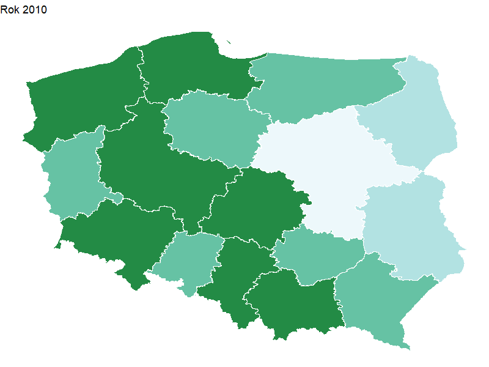

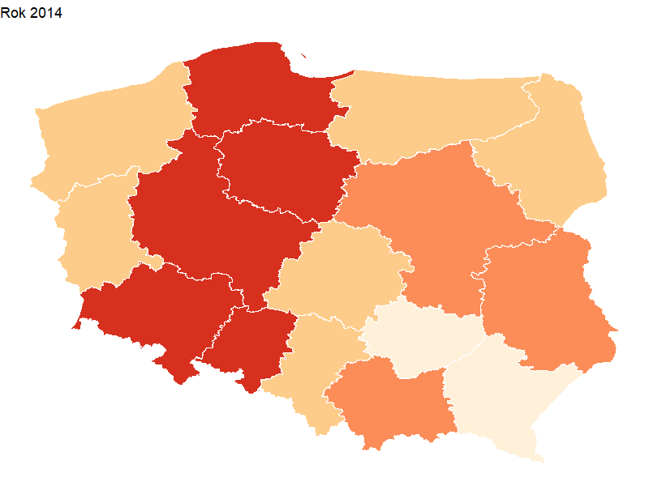

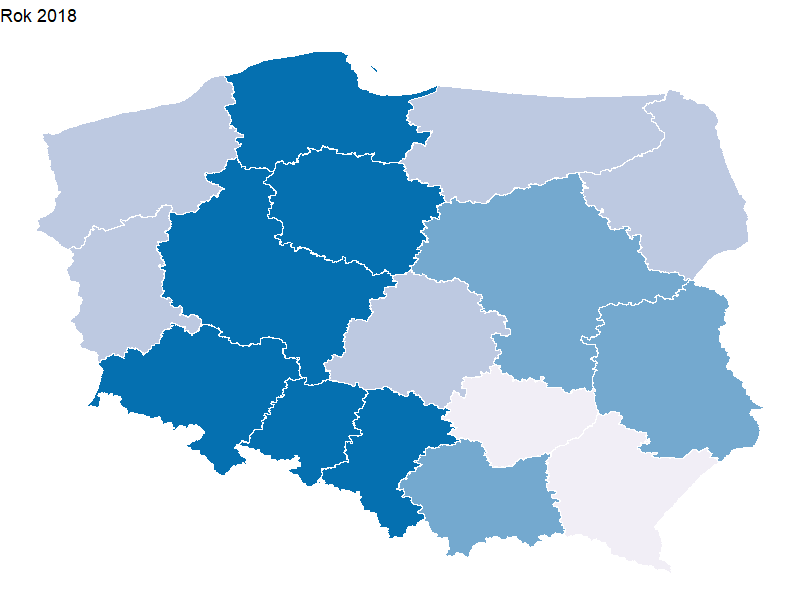

Podział dla roku 2014 jest prawie identyczny jak ten wykonany dla roku 2018. Jedyną różnicą jest zmiana klasyfikacji województwa śląskiego. Największe zmiany wśród klasyfikacji dokonały się pomiędzy 2010 a 2014 rokiem.

Zmiana przynależności śląska w 2018 roku wynika w znacznej mierze ze wzrostu odsetka studentów cudzoziemców oraz zmniejszenia się o blisko połowę udziału zarejestrowanych osób bezrobotnych z dyplomem uczelni wyższej w liczbie osób w wieku produkcyjnym. Pozostałe województwa zostały zaklasyfikowane tak samo w 2014 jak i 2018 roku.

Pomiędzy 2010 a 2014 rokiem województwa pomorskie, wielkopolskie oraz dolnośląskie nie zmieniły klasy i utrzymały się w klasie o wartościach najbardziej zbliżonych do średniej krajowej. Województwo zachodniopomorskie odnotowało o wiele większy spadek liczby studentów na 10 tys. ludności niż pozostałe województwa środkowo-zachodniej Polski dlatego w 2014 zostało ujęte razem z województwami północno-wschodniej Polski. Podobna sytuacja wystąpiła w odniesieniu do w. łódzkiego. Podkarpacie wraz z województwem świętokrzyskim zostało w 2014 roku wyodrębnione jako osobna klasa. Przyczyną był zwiększający się udział osób bezrobotnych z wyższym wykształceniem w liczbie osób w wieku produkcyjnym. Do stanowiącego osobną klasę w 2010 roku Mazowsza w 2014 dołączyła Małopolska ze względu na bardzo zbliżone wartości odsetka przyznanych stypendiów oraz liczby studentów na 10 tys. mieszkańców. Małopolska była jedynym województwem gdzie odnotowano wzrost tej ostatniej cechy w 2014 roku (w stosunku do 2010 roku).

### 5. Podsumowanie

Podział metodą Warda, ze względu zarówno na metodę jak i liczbę klas wskazuje różnice pomiędzy podziałem dokonanym metodą k-średnich i otrzymanymi wartościami średnimi dla danej klasy. Jest to spowodowane między innymi tym, iż wartość danej cechy dla danej klasy jest liczona jako średnia województw wchodzących w skład danej grupy. Mimo, że wartość pojedynczej zmiennej dla danego województwa będzie bliższa klasie A, może być ono przydzielone do klasy B, ze względu na pozostałe cechy, tym samym zmieniając średnią wartość tej pojedynczej cechy dla całej klasy. Badanie ma na celu pogrupowanie województw ze względu na podobieństwa, ale również – co niemniej istotne – rozdzielnie województw o wartościach cech znacznie od siebie różnych.

Z powyższych badań wynika, że poszczególne województwa zmieniały klasy do których były przyporządkowane natomiast nie nastąpiły drastyczne zmiany - zarówno poprawy jak i pogorszenie wartości cech. Ciekawym uzupełnieniem przeprowadzonych badań byłoby powiększenie zbioru zmiennych o te spoza Banku Danych Lokalnych i opracowań GUS oraz stworzenie rankingu województw ze względu na badane cechy.

[^1]: Główny Urząd Statystyczny *“Szkolnictwo wyższe w roku akademickim 2018/2019”* Warszawa 2019
[^2]: M. Walesiak, E. Gatnar *“Statystyczna analiza danych z wykorzystaniem programu R”* Warszawa 2009, s. 416
[^3]: C. Subbalakshmi, G. Rama Krishna, S Krishna Mohan Rao, P Venketeswa Rao *“A Method to Find Optimum Number of Clusters Based on Fuzzy Silhouette on Dynamic Data Set”* India 2014
[^4]: Główny Urząd statystyczny *Regionalne zróżnicowanie jakości życia w 2018 r*
[^5]: M. Walesiak, E. Gatnar *“Statystyczna analiza danych z wykorzystaniem programu R”* Warszawa 2009, s. 413-416